# 16 prep

```r
library(tidyverse)
```

# bad lm

Why is it weird to fit a linear model to binary outcome data?

```r
mallow <- read_csv("https://uoepsy.github.io/data/mallow.csv")
```

```r
mallow_lm <- lm(taken ~ age, data = mallow)
```

## check assumptions of bad lm

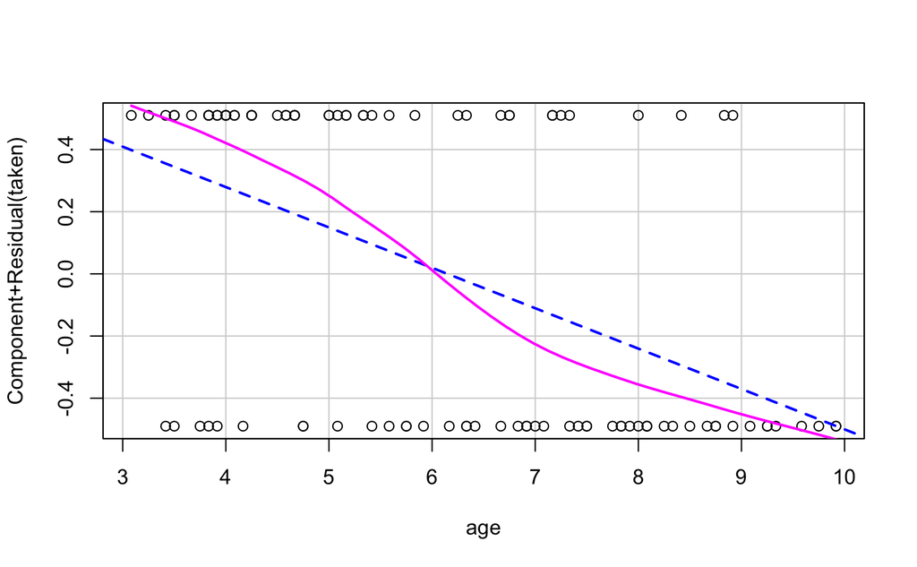

```r
car::crPlots(mallow_lm)
```

non-linear

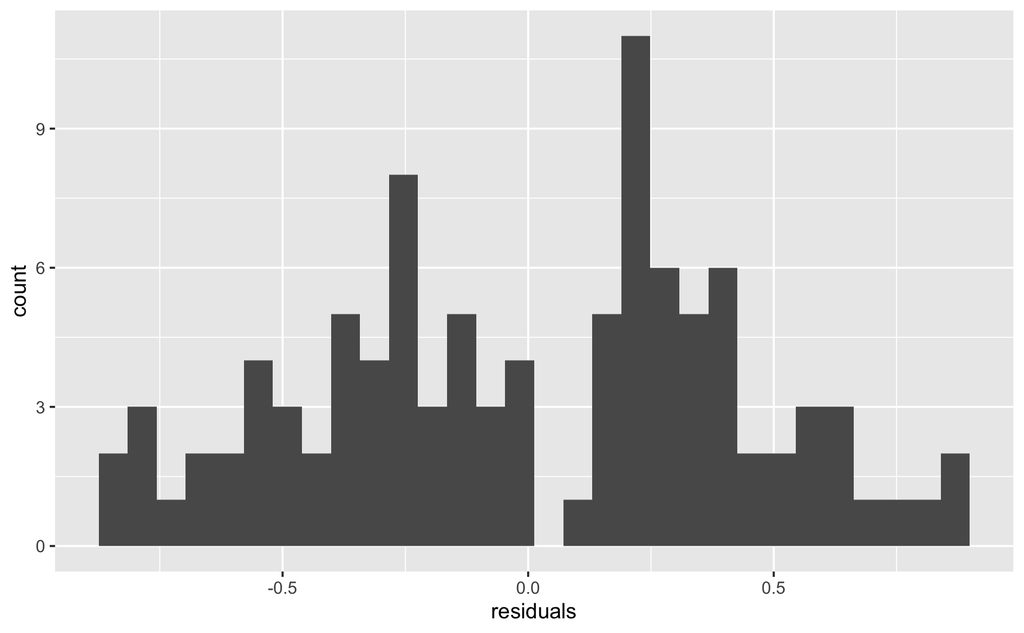

```r
tibble(residuals=mallow_lm$residuals) |>
  ggplot(aes(x = residuals)) +
  geom_histogram()
```

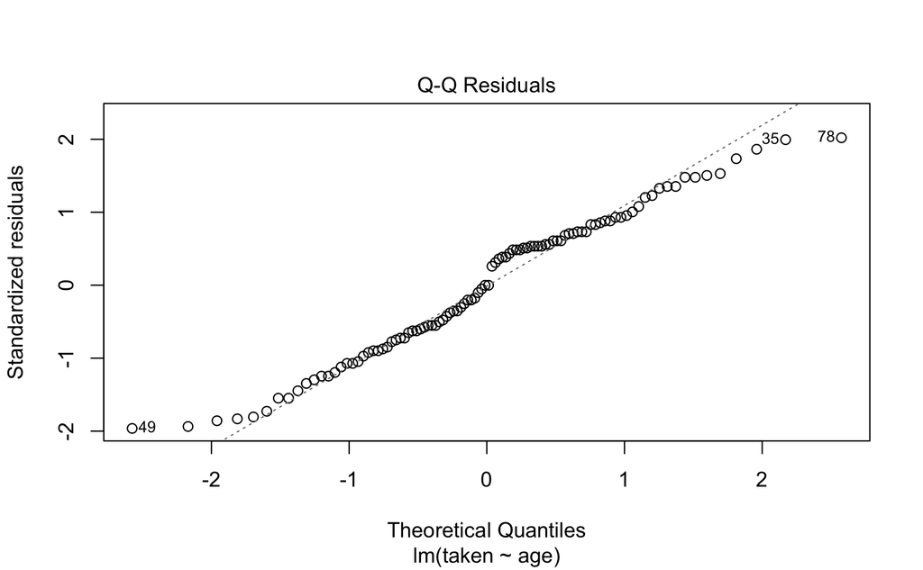

```r
plot(mallow_lm, which = 2)
```

not normal! pattern consistent with bounded outcome data.

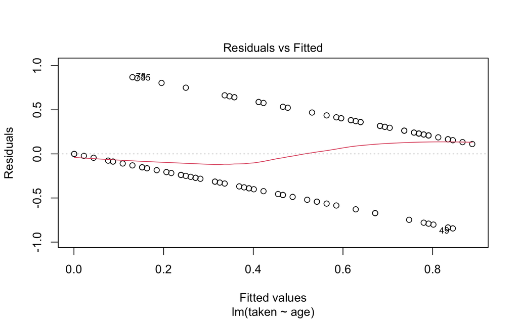

```r
plot(mallow_lm, which = 1)
```

again, consistent with only two possible outcome values.

## try ot interpret coefs?

```r
summary(mallow_lm)
```

```
Call:
lm(formula = taken ~ age, data = mallow)

Residuals:
     Min       1Q   Median       3Q      Max
-0.84500 -0.32803 -0.00053  0.31739  0.86955

Coefficients:
            Estimate Std. Error t value Pr(>|t|)
(Intercept)  1.28890    0.14620   8.816 4.47e-14 ***
age         -0.12992    0.02269  -5.726 1.12e-07 ***
---
Signif. codes:  0 ‘***’ 0.001 ‘**’ 0.01 ‘*’ 0.05 ‘.’ 0.1 ‘ ’ 1

Residual standard error: 0.4371 on 98 degrees of freedom
Multiple R-squared:  0.2507,    Adjusted R-squared:  0.2431
F-statistic: 32.79 on 1 and 98 DF,  p-value: 1.125e-07
```

if you either took a marshmallow = 1 or didn’t = 0, then what does it mean for the model to estimate that at age zero, the estimated outcome is 1.29? you SUPER took the marshmallow? weird.

## look at model predictions

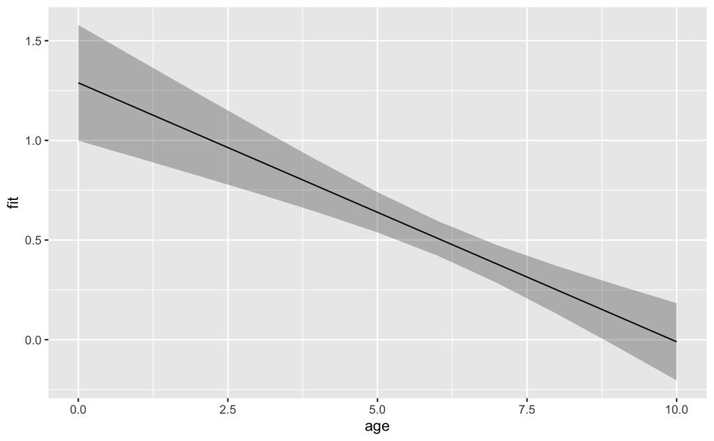

```r
effects::effect(term = 'age', mod = mallow_lm, xlevels = list(age = 0:10)) |>
    as.data.frame() |>
    ggplot(aes(x = age, y = fit)) +
    geom_line() +
    geom_ribbon(aes(ymin = lower, ymax = upper), alpha = 0.3)
```

imposs values. (do this or coefs. i think this is better bc impossibility is clearer.)

# plot logistic curve

copy code

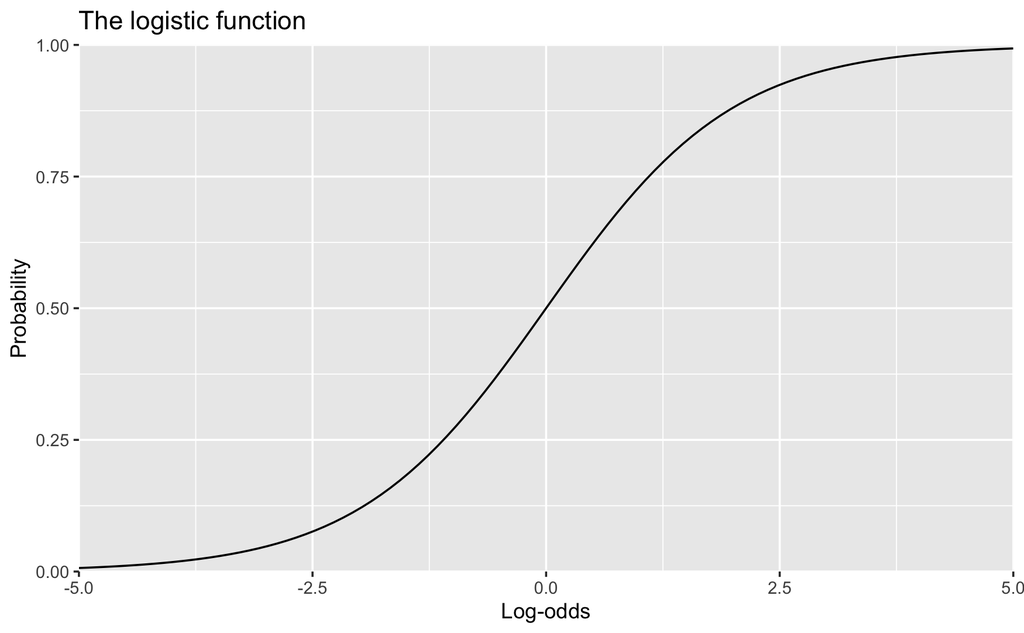

```r
p_logistic <- tibble(
  logodds = seq(-5, 5, length.out = 100),
  prob = plogis(logodds)
) |>
  ggplot(aes(x = logodds, y = prob)) +
  geom_line() +
  scale_x_continuous(expand = c(0, 0)) +
  scale_y_continuous(expand = c(0, 0), limits = c(0, 1)) +
  labs(
    y = 'Probability',
    x = 'Log-odds'
  ) +
  ggtitle('The logistic function')

p_logistic
```

# transforming probs to log-odds

Based on the plot of the logistic curve, guess the approximate log-odds value that corresponds to each of these probabilities. Write down your guess.

```r
probs <- c(0.33, 0.05, 0.99, 0.2, 0, 1)
```

Now compute the actual log-odds value for each probability and compare your guesses.

```r
qlogis(probs)
```

```
[1] -0.7081851 -2.9444390  4.5951199 -1.3862944       -Inf        Inf
```

Try running the following lines of code. why does each one fail?

```r
qlogis(-5)
```

```
[1] NaN
```

```r
qlogis(1.5)
```

```
[1] NaN
```

```r
qlogis(100)
```

```
[1] NaN
```

# transforming log-odds to probs

guess

```r
logodds <- c(-10, -2, 0.2, 5, 10)
```

```r
plogis(logodds)
```

```
[1] 4.539787e-05 1.192029e-01 5.498340e-01 9.933071e-01 9.999546e-01
```

Can you find any values that make `plogis()` fail?

If you find some values, what values are they, and why does `plogis()` fail?

If there are no values, why does `plogis()` not fail?

```r
plogis(-Inf)
```

```
[1] 0
```

```r
plogis(Inf)
```

```
[1] 1
```

# why back-transforming indiv model coefs into prob space does not work

Imagine a line in log-odds space. That line has an intercept of 1 and a slope of 0.5.

Here’s some data that corresponds to that line:

```r
logodds_line_df <- tibble(
    predictor = 0:5,
    logodds_success = 1 + 0.5 * predictor
)

logodds_line_df
```

| predictor | logodds_success |
| --- | --- |
| 0 | 1.0 |
| 1 | 1.5 |
| 2 | 2.0 |
| 3 | 2.5 |
| 4 | 3.0 |
| 5 | 3.5 |

To plot the line:

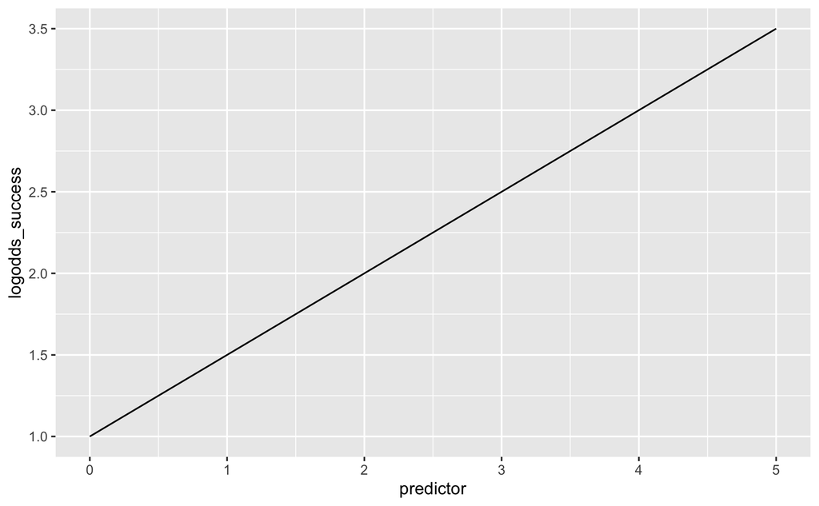

```r
logodds_line_df |>
    ggplot(aes(x = predictor, y = logodds_success)) +
    geom_line()
```

back-transform intercept to prob space.

```r
plogis(1)
```

```
[1] 0.7310586
```

do the wrong thing and back-transform slope to prob space using `plogis()` as well, we get

```r
plogis(0.5)
```

```
[1] 0.6224593
```

what value would this line predict for predictor = 1? predictor = 2?

```r
0.73 + 0.62 * 2
```

```
[1] 1.97
```

so if that was a line in probability space, it would look like

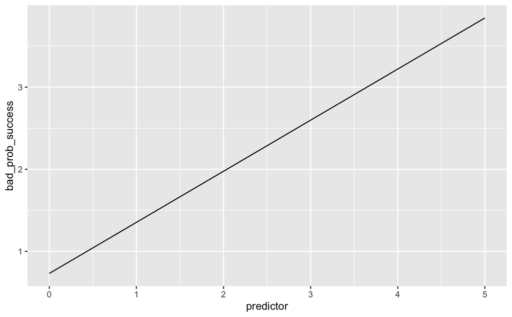

```r
tibble(
    predictor = 0:5,
    bad_prob_success = plogis(1) + plogis(0.5) * predictor
) |>
    ggplot(aes(x = predictor, y = bad_prob_success)) +
    geom_line()
```

how to back-transform this line to probabilities *correctly*:

we can only back-transform actual log-odds values, NOT differences between log-odds values.

| predictor | logodds_success | probs_success |
| --- | --- | --- |
| 0 | 1.0 | 0.7310586 |
| 1 | 1.5 | 0.8175745 |
| 2 | 2.0 | 0.8807971 |
| 3 | 2.5 | 0.9241418 |
| 4 | 3.0 | 0.9525741 |
| 5 | 3.5 | 0.9706878 |

and if you plot it, notice that it’s not a straight line, so it doesn’t make sense to have a constant slope in probability space!

[figure not shown]

```r
plogis(1 + 0.5*0)
```

```
[1] 0.7310586
```

```r
plogis(1 + 0.5*1)
```

```
[1] 0.8175745
```

```r
plogis(1 + 0.5*2)
```

```
[1] 0.8807971
```